# Bio201 Final Project Calorie Low

Yingyue Ding, Kevin Huang, Sunyimeng Lei, Clarissa Halim

11/18/2019

https://github.com/dyy980617/Bio201ThursPM/tree/master/Bio201ThursPM

Research Question: How does the consumption of a prebiotic effect the gut microbiomal community(diversity, changes in taxon abundance) among people who have different calories diet?

Since we got significant difference from BRMPS consumption in the BRMPS Rmd, In this Rmd we will be testing how a fixed routine of low Cal daily with the consumption of BRMPS will effect once gut microbiomal commnity in regard of richness and simpson diversity index, and beta divesity.We selceted for quantity compliant. Our hypothesis is there gonna be significant difference in these index.

# Load packages

```r
library(tidyverse)
library(readxl)
library(broom)
library(cowplot)
library(agricolae)
library(phyloseq); packageVersion("phyloseq")
library(vegan)
set.seed(7)
```

# Import data

### Sequence variants

Import shared/ESV/OTU table and format for phyloseq. Phyloseq works by matching rownames across matrix objects (This is similar to how we matched columns in joins of data frames). A two-dimensional matrix in R looks just like a data frame, however R matrices can be three-dimensional. A three-dimensional object is created when multiple two-dimensional objects are combined (we’ll work through this in the upcoming sections).

```r
#convert txt to valid cvs, I have done this step, and upload "species_avg_shared.csv" to our reporsitory.

#species_avg_shared <- read_delim("C:/Users/tina5/OneDrive/Bio201ThursPM/raw_data/species_avg_shared.txt",
#                            delim = "\t", escape_double = FALSE,
#                            trim_ws = TRUE, na=c("NA"),
#                           col_types = list()) %>%   #import txt
# rename(participant_id_week = Participant_ID) %>%
#  select(-Semester)#don't need
#  species_avg_shared$participant_id_week = paste(species_avg_shared$participant_id_week,
#                                                 species_avg_shared$Study_week,
#                                                 sep="_") #create a combined name
#write.csv(species_avg_shared,file="C:/Users/tina5/OneDrive/Bio201ThursPM/curated_data/species_avg_shared.csv",quote=F,row.names = F)


species_avg_shared<-read_delim("~/Documents/Bio201ThursPM/curated_data/species_avg_shared.csv",
                            delim = ",", escape_double = FALSE,
                            trim_ws = TRUE, na=c("NA"),
                            col_types = list())
sv_table <- read_delim("~/Documents/Bio201ThursPM/curated_data/species_avg_shared.csv",
                            delim = ",", escape_double = FALSE,
                            trim_ws = TRUE, na=c("NA"),
                            col_types = list())  %>%
  mutate_if(is.numeric, round, digits = 0) %>%
  column_to_rownames(var = "participant_id_week") %>%
  as.matrix() %>%   #convert data frame to matrix object
  otu_table(., taxa_are_rows = FALSE) #specify type of phyloseq object
```

### Taxa

Import taxonomy table and format for phyloseq.

```r
taxa <- read_delim("~/Documents/Bio201ThursPM/curated_data/seqvar_classifications.csv",
                            delim = ",", escape_double = FALSE,
                            trim_ws = TRUE, na=c("NA"),
                            col_types = list()) %>%
  column_to_rownames(var = "sv") %>% #sequence variants (OTUs) need to be made into row names
  as.matrix() %>%
  tax_table(.)  #specify type of phyloseq object
```

### Participant data

Import sample data (where a sample is an individual microbiome sample) and format for phyloseq.

```r
#select high calorie diet participant
diet_f15_ASA2_cal <- read_delim("~/Documents/Bio201ThursPM/raw_data/diet_f15_ASA2.txt",
                            delim = "\t", escape_double = FALSE,
                            trim_ws = TRUE,
                            col_types = list()) %>%
  select(Participant_ID,Semester,Calories)

diet_f17_ASA2_cal <- read_delim("~/Documents/Bio201ThursPM/raw_data/diet_f17_ASA2.txt",
                            delim = "\t", escape_double = FALSE,
                            trim_ws = TRUE,
                            col_types = list()) %>%
  select(Participant_ID,Semester,Calories)

diet_w17_ASA2_cal <- read_delim("~/Documents/Bio201ThursPM/raw_data/diet_w17_ASA2.txt",
                            delim = "\t", escape_double = FALSE,
                            trim_ws = TRUE,
                            col_types = list()) %>%
  select(Participant_ID,Semester,Calories)

diet_MFP_cal <- read_delim("~/Documents/Bio201ThursPM/raw_data/diet_MFP.txt",
                            delim = "\t", escape_double = FALSE,
                            trim_ws = TRUE,
                            col_types = list()) %>%
  select(Participant_ID,Semester,Calories)


diet_1_cal <- dplyr::union(diet_f15_ASA2_cal, diet_f17_ASA2_cal)
diet_2_cal <- dplyr::union(diet_w17_ASA2_cal, diet_MFP_cal)
diet_all_cal <- dplyr::union(diet_1_cal, diet_2_cal) %>%
  add_column(cal_status = "-") %>%
  rename_all(tolower)

diet_all_cal$cal_status[diet_all_cal$calories > 2500] <- "high"
diet_all_cal$cal_status[diet_all_cal$calories <= 2500] <- "low"
```

```r
all_data_wkly <- read_delim("~/Documents/Bio201ThursPM/raw_data/all_data_wkly.txt",
                            delim = "\t", escape_double = FALSE,
                            trim_ws = TRUE,
                            col_types = cols(Bristol_numeric = col_number(),
                                             Bristol_score = col_character(),
                                             pH = col_number())) %>%
  rename_all(tolower) %>%
  mutate(participant_id_week = participant_id)
all_data_wkly_cal <- inner_join(x = all_data_wkly, y = diet_all_cal,
                                  by = c( "participant_id"))

all_data_wkly_cal$participant_id_week = paste(all_data_wkly_cal$participant_id,
                                                 all_data_wkly_cal$study_week,
                                                 sep="_")  #match with "sv_table"

all_data_wkly_inner <- inner_join(x = all_data_wkly_cal, y = species_avg_shared,
                                  by = c( "participant_id_week")) %>%
                      select( participant_id_week, study_week, semester.x, supplement_consumed,
                              quantity_compliant, frequency, ph_median, ph_mean, bristol_median,
                              bristol_mean, blood_glucose_median, blood_glucose_mean, acetate_median,
                              acetate_mean, butyrate_median ,butyrate_mean, propionate_median,
                              propionate_mean,cal_status) %>%
                      rename(semester = semester.x) %>%

                      distinct(., participant_id_week, .keep_all = TRUE) %>% #remove duplicate participant ids
                      column_to_rownames(var = "participant_id_week") %>% #participant IDs need to be made into row names
                      sample_data(.) #specify type of phyloseq object
```

# Create phyloseq objects

Phyloseq is an R package that has a suite of functions that make microbial community anaylsis a bit simpler. https://joey711.github.io/phyloseq/index.html It requires the data to be structured in three critical files (1) sequence variant (or OTU) table that contains counts of each sequence; (2) Taxanomic information that contains classifications from Phylum to species for each sequence variant; (3) sample information, which is the participant information we have been working with so far this semester. We imported these three files in the section above, now we have to combine them into one object.

```r
physq_obj <- phyloseq(sv_table, taxa, all_data_wkly_inner) #combine three phyloseq objects created above

physq_obj #view dimentions of new object
```

```
## phyloseq-class experiment-level object
## otu_table()   OTU Table:         [ 1160 taxa and 1148 samples ]
## sample_data() Sample Data:       [ 1148 samples by 18 sample variables ]
## tax_table()   Taxonomy Table:    [ 1160 taxa by 1 taxonomic ranks ]
```

# Richness

### Calculate richness

```r
# Caculate richness

richness_df_cal <- physq_obj %>%
  subset_samples(study_week == "week1" | study_week == "week3") %>%
  subset_samples(supplement_consumed == "BRMPS")%>%
  subset_samples(quantity_compliant == "yes") %>%
  subset_samples(cal_status == "low") %>% #subset for weeks of interest
 # subset_taxa(Species == starts_with("Bifidobacterium"))
  estimate_richness(., split = TRUE,  measures = c("Observed")) %>% #calculate richness
  rownames_to_column(var = "participant_id_week") %>% #reverse phyloseq object formatting

  inner_join(all_data_wkly_cal, by = "participant_id_week")%>%
select(participant_id, study_week, Observed)%>%
  rename(richness_cal = Observed)


# save richness data
write_delim(richness_df_cal, path = "~/Documents/Bio201ThursPM/curated_data/richness_df_cal_low.txt", delim = "\t")
```

### Plot richness

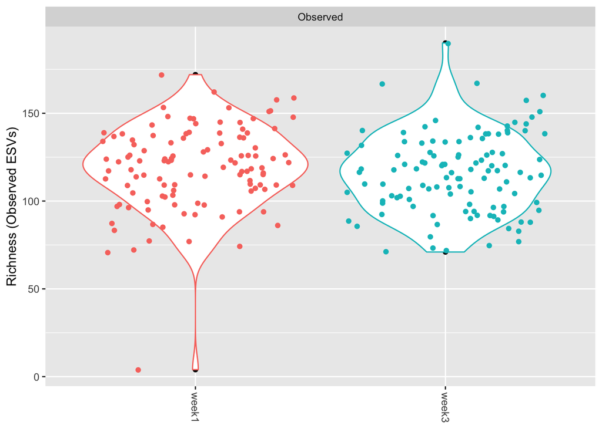

```r
# Plot richness
rich1_cal <- physq_obj %>%
  subset_samples(., cal_status == "low") %>%
  subset_samples(supplement_consumed == "BRMPS")%>%
  subset_samples(quantity_compliant == "yes") %>%
  subset_samples(., study_week == "week1" | study_week == "week3") %>%
  plot_richness(., "study_week", measures = c("Observed")) +
  ylab("Richness (Observed ESVs)") + xlab(NULL)

rich2_cal <- rich1_cal +
  geom_violin(aes(color = study_week)) + #add violin in color
  geom_jitter(aes(color = study_week)) +  #add individual points in color
  theme(legend.position = "none")
rich2_cal
```

```r
# save plot
save_plot(filename = "~/Documents/Bio201ThursPM/figures/rich2_cal_low.pdf",
          plot = rich2_cal,
          nrow = 1, ncol = 2,
          base_aspect_ratio = 1.1)
```

```r
richness_df_cal %>%
  group_by(study_week) %>%
summarise(sample_size = n())
```

```
## # A tibble: 2 x 2
##   study_week sample_size
##   <chr>            <int>
## 1 week1              115
## 2 week3              115
```

```r
richness_normal_cal<-richness_df_cal

  shapiro.test(richness_normal_cal$richness_cal)
```

```
##
##  Shapiro-Wilk normality test
##
## data:  richness_normal_cal$richness_cal
## W = 0.97923, p-value = 0.001845
```

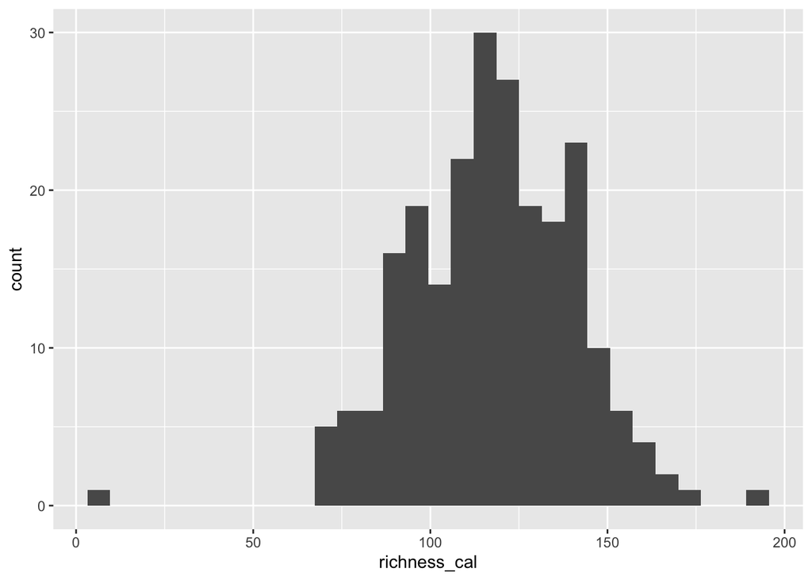

```r
ggplot(richness_normal_cal, aes(x=richness_cal)) +
  geom_histogram()
```

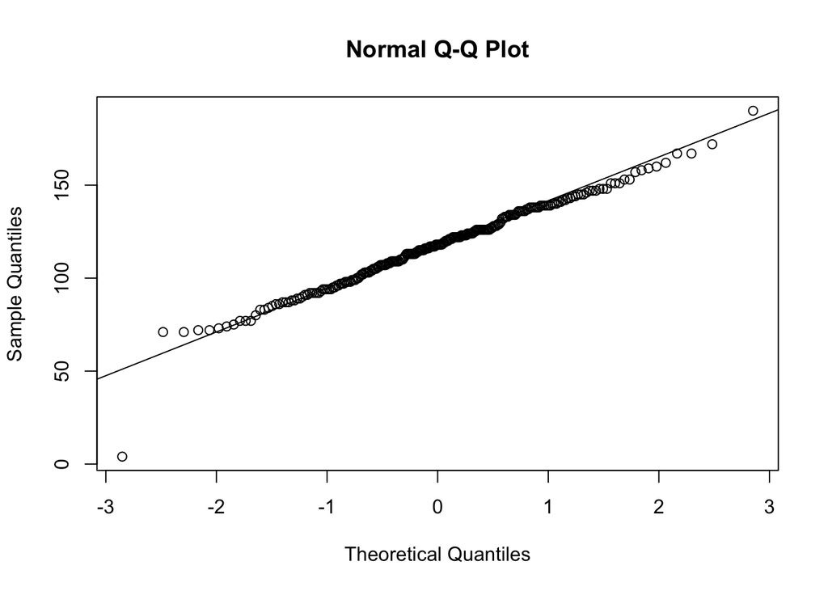

```r
qqnorm(richness_normal_cal$richness_cal); qqline(richness_normal_cal$richness_cal)
```

```r
richness_wk1_cal<- richness_df_cal%>%
  filter(study_week == "week1")
richness_wk3_cal <- richness_df_cal %>%
  filter(study_week == "week3")
var.test(x = richness_wk1_cal$richness_cal,
         y = richness_wk3_cal$richness_cal,
         alternative = "two.sided")
```

```
##
##  F test to compare two variances
##
## data:  richness_wk1_cal$richness_cal and richness_wk3_cal$richness_cal
## F = 1.1291, num df = 114, denom df = 114, p-value = 0.5179
## alternative hypothesis: true ratio of variances is not equal to 1
## 95 percent confidence interval:
##  0.7806982 1.6329494
## sample estimates:
## ratio of variances
##           1.129088
```

```r
richness_df2_cal <- inner_join(x = richness_wk1_cal, y = richness_wk3_cal,
                    by = c("participant_id")) %>%
  rename(richness_wk1_cal = richness_cal.x,
         richness_wk3_cal = richness_cal.y)


t.test(x = richness_df2_cal$richness_wk1_cal,
       y = richness_df2_cal$richness_wk3_cal,
       alternative = "two.sided", paired = TRUE, var.equal = TRUE)
```

```
##
##  Paired t-test
##
## data:  richness_df2_cal$richness_wk1_cal and richness_df2_cal$richness_wk3_cal
## t = 2.1525, df = 113, p-value = 0.03349
## alternative hypothesis: true difference in means is not equal to 0
## 95 percent confidence interval:
##  0.3001681 7.2436916
## sample estimates:
## mean of the differences
##                 3.77193
```

p-value = 0.03349, significant difference in richness when consumpetion is BRMPS AND calorie status is fixed to low level（Control variable).

# Simpson

To calculate Simpson diveristy index we repeat the process above for calcuating richness, the only thing we have to change is the `measures = c("Simpson")` argument for the plot_richness() and estimate_richness() functions.

### Calculate simpson

```r
simpson_df_cal <- physq_obj %>%
  subset_samples(., cal_status == "low") %>%
  subset_samples(quantity_compliant == "yes") %>%
  subset_samples(supplement_consumed == "BRMPS")%>%
  subset_samples(., study_week == "week1" | study_week == "week3") %>% #subset for weeks of interest
  estimate_richness(., split = TRUE,  measures = c("Simpson")) %>% #calculate simpson
  rownames_to_column(var = "participant_id_week") %>% #reverse phyloseq object formatting

  inner_join(all_data_wkly_cal, by = "participant_id_week")%>%
select(participant_id, study_week, Simpson)%>%
  rename(simpson_cal = Simpson)

# save Simpson data
write_delim(simpson_df_cal, path = "~/Documents/Bio201ThursPM/curated_data/simpson_df_cal_low.txt", delim = "\t")
```

### Plot simpson

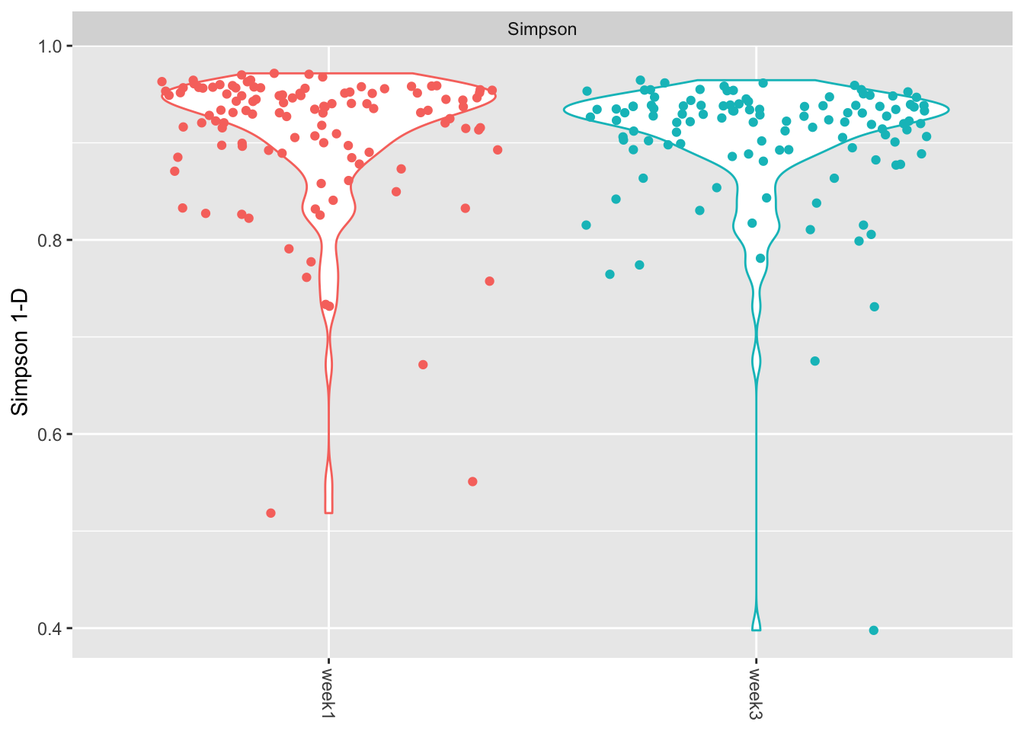

```r
# Simpson
simp1_cal <- physq_obj %>%
  subset_samples(., cal_status == "low") %>%
  subset_samples(supplement_consumed == "BRMPS")%>%
  subset_samples(quantity_compliant == "yes") %>%
  subset_samples(., study_week == "week1" | study_week == "week3") %>%
  plot_richness(., "study_week", measures = c("Simpson")) +
  ylab("Simpson 1-D") + xlab(NULL)
simp1_cal$layers <- simp1_cal$layers[-1] #drop geom_point
simp2_cal <- simp1_cal +
  geom_violin(aes(color = study_week)) + #add violin in color
  geom_jitter(aes(color = study_week)) +  #add individual points in color
  theme(legend.position = "none")
simp2_cal
```

```r
# save plot
save_plot(filename = "~/Documents/Bio201ThursPM/figures/simp2_cal_low.pdf",
          plot = simp2_cal,
          nrow = 1, ncol = 2,
          base_aspect_ratio = 1.1)
```

```r
simpson_df_cal %>%
  group_by(study_week) %>%
summarise(sample_size = n())
```

```
## # A tibble: 2 x 2
##   study_week sample_size
##   <chr>            <int>
## 1 week1              115
## 2 week3              115
```

```r
simpson_normal_cal<-simpson_df_cal

  shapiro.test(simpson_normal_cal$simpson_cal)
```

```
##
##  Shapiro-Wilk normality test
##
## data:  simpson_normal_cal$simpson_cal
## W = 0.67646, p-value < 2.2e-16
```

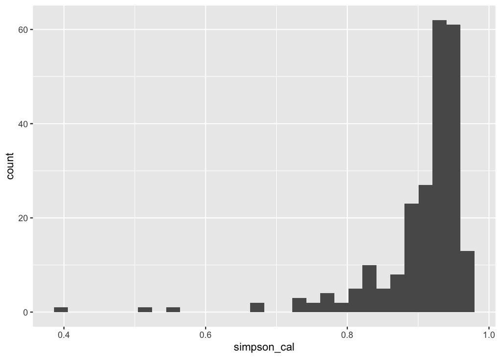

```r
ggplot(simpson_normal_cal, aes(x=simpson_cal)) +
  geom_histogram()
```

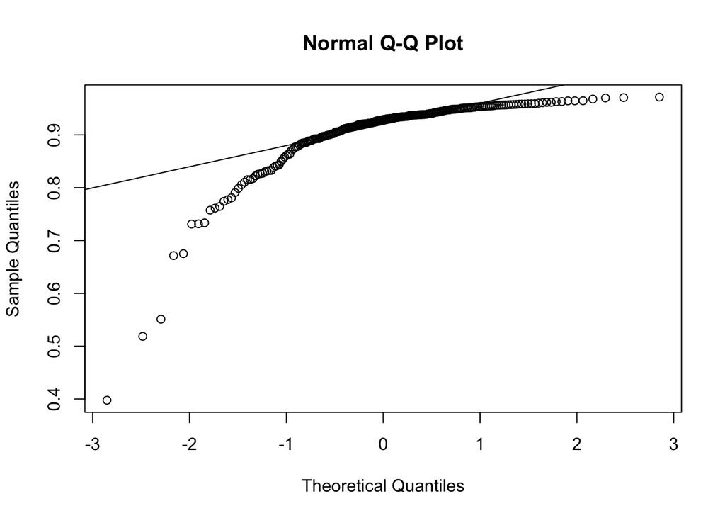

```r
qqnorm(simpson_normal_cal$simpson_cal); qqline(simpson_normal_cal$simpson_cal)
```

```r
simpson_wk1_cal<- simpson_df_cal%>%
  filter(study_week == "week1")
simpson_wk3_cal <- simpson_df_cal %>%
  filter(study_week == "week3")
var.test(x = simpson_wk1_cal$simpson_cal,
         y = simpson_wk3_cal$simpson_cal,
         alternative = "two.sided")
```

```
##
##  F test to compare two variances
##
## data:  simpson_wk1_cal$simpson_cal and simpson_wk3_cal$simpson_cal
## F = 1.1748, num df = 114, denom df = 114, p-value = 0.3912
## alternative hypothesis: true ratio of variances is not equal to 1
## 95 percent confidence interval:
##  0.8122735 1.6989939
## sample estimates:
## ratio of variances
##           1.174754
```

```r
simpson_df2_cal <- inner_join(x = simpson_wk1_cal, y = simpson_wk3_cal,
                    by = c("participant_id")) %>%
  rename(simpson_wk1_cal = simpson_cal.x,
         simpson_wk3_cal = simpson_cal.y)


wilcox.test(x = simpson_df2_cal$simpson_wk1_cal,
       y = simpson_df2_cal$simpson_wk3_cal,
       alternative = "two.sided", paired = TRUE)
```

```
##
##  Wilcoxon signed rank test with continuity correction
##
## data:  simpson_df2_cal$simpson_wk1_cal and simpson_df2_cal$simpson_wk3_cal
## V = 4289, p-value = 0.004256
## alternative hypothesis: true location shift is not equal to 0
```

p-value = 0.004256 significant difference in simpson when consumpetion is BRMPS AND calorie status is fixed to low level（Control variable）.

# Beta diveristy

### Conduct ordination analysis

This step calculates the diveristy index (using Bray Curtis in the example below), and does the ranking process of the diveristy indices to generate the information necessary to create a two-dimensional plot. Notice the arguments in the ordinate function; the index, Bray Curtis (“bray”) or Jaccard (“jaccard”), is specified in the distance agurment, and with either of these metrics we will use method = “NMDS”. The place were you might want to make some modifications is the k (this should be somewhere between 1-3), the maximum number of iterations (more than 100 will take several minutes to calcaulte), and the inital number of interations to try (50 in the example below). These can be modified to reduce the stress, with the goal of a number less than 0.20 (the lower the better).

```r
# Bray Curtis
physq_sub <- physq_obj %>%
 subset_samples(quantity_compliant == "yes") %>%

subset_samples(supplement_consumed == "BRMPS")%>%

subset_samples(study_week == "week1" | study_week == "week3")%>%
subset_samples(cal_status == "low")
physq_sub
```

```
## phyloseq-class experiment-level object
## otu_table()   OTU Table:         [ 1160 taxa and 228 samples ]
## sample_data() Sample Data:       [ 228 samples by 18 sample variables ]
## tax_table()   Taxonomy Table:    [ 1160 taxa by 1 taxonomic ranks ]
```

```r
physq_bc <- ordinate(physq_sub,
                      method = "NMDS",
                      k=3, maxit=100, try=50,
                      distance = "bray")
```

```
## Square root transformation
## Wisconsin double standardization
## *** No convergence -- monoMDS stopping criteria:
##     50: no. of iterations >= maxit
```

```r
physq_bc
```

```
##
## Call:
## metaMDS(comm = veganifyOTU(physeq), distance = distance, k = 3,      try = 50, maxit = 100)
##
## global Multidimensional Scaling using monoMDS
##
## Data:     wisconsin(sqrt(veganifyOTU(physeq)))
## Distance: bray
##
## Dimensions: 3
## Stress:     0.1332072
## Stress type 1, weak ties
## No convergent solutions - best solution after 50 tries
## Scaling: centring, PC rotation, halfchange scaling
## Species: expanded scores based on 'wisconsin(sqrt(veganifyOTU(physeq)))'
```

```r
# Jaccard
physq_j <- ordinate(physq_sub,
                      method = "NMDS",
                      k=3, maxit=100, try=50,
                      distance = "jaccard")
```

```
## Square root transformation
## Wisconsin double standardization
## *** No convergence -- monoMDS stopping criteria:
##     50: no. of iterations >= maxit
```

```r
physq_j
```

```
##
## Call:
## metaMDS(comm = veganifyOTU(physeq), distance = distance, k = 3,      try = 50, maxit = 100)
##
## global Multidimensional Scaling using monoMDS
##
## Data:     wisconsin(sqrt(veganifyOTU(physeq)))
## Distance: jaccard
##
## Dimensions: 3
## Stress:     0.1329018
## Stress type 1, weak ties
## No convergent solutions - best solution after 50 tries
## Scaling: centring, PC rotation, halfchange scaling
## Species: expanded scores based on 'wisconsin(sqrt(veganifyOTU(physeq)))'
```

### Plot results and Modifications of ordination plots

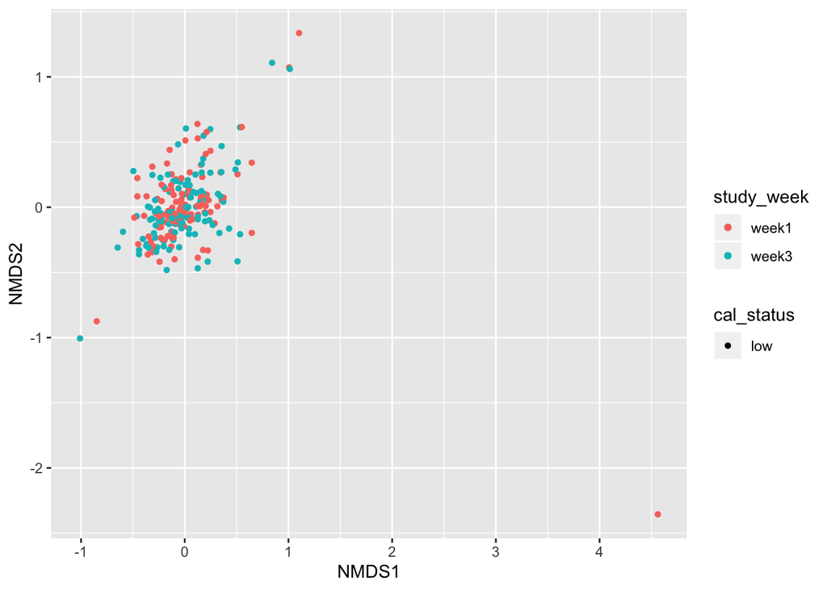

```r
# Bray Curtis
ordplot1 <- plot_ordination(physeq = physq_sub,
                     ordination = physq_bc,
                     type = "samples",
                     color = "study_week",
                     shape = "cal_status")
print(ordplot1)
```

```r
save_plot(filename = "~/Documents/Bio201ThursPM/figures/bc_cal_low.pdf",
          plot = ordplot1,
          nrow = 1, ncol = 2,
          base_aspect_ratio = 1.1)
```

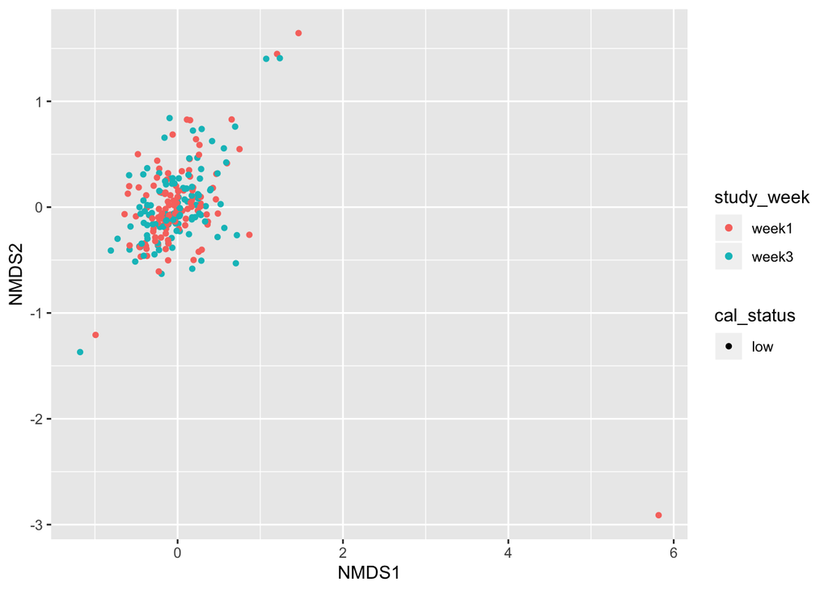

```r
# Jaccard
ordplot2 <- plot_ordination(physeq = physq_sub,
                     ordination = physq_j,
                     type = "samples",
                     color = "study_week",
                     shape = "cal_status")
print(ordplot2)
```

```r
save_plot(filename = "~/Documents/Bio201ThursPM/figures/ja_cal_low.pdf",
          plot = ordplot2,
          nrow = 1, ncol = 2,
          base_aspect_ratio = 1.1)
```

### Statistical test

```r
# run Bray Curtis test
dat_bray <- phyloseq::distance(physq_sub, method = "bray")

sampledf <- physq_sub %>%
  sample_data(.) %>%
  as(., "data.frame")


adn_res <- adonis(formula = dat_bray ~ study_week,
                  data = sampledf)


print(adn_res)
```

```
##
## Call:
## adonis(formula = dat_bray ~ study_week, data = sampledf)
##
## Permutation: free
## Number of permutations: 999
##
## Terms added sequentially (first to last)
##
##             Df SumsOfSqs MeanSqs F.Model    R2 Pr(>F)
## study_week   1     0.597 0.59664  2.7439 0.012  0.001 ***
## Residuals  226    49.141 0.21744         0.988
## Total      227    49.738                 1.000
## ---
## Signif. codes:  0 '***' 0.001 '**' 0.01 '*' 0.05 '.' 0.1 ' ' 1
```

```r
# run Jaccard test
dat_ja <- phyloseq::distance(physq_sub, method = "jaccard")

sampledf <- physq_sub %>%
  sample_data(.) %>%
  as(., "data.frame")


adn_2 <- adonis(formula = dat_ja ~ study_week ,
                  data = sampledf)


print(adn_2)
```

```
##
## Call:
## adonis(formula = dat_ja ~ study_week, data = sampledf)
##
## Permutation: free
## Number of permutations: 999
##
## Terms added sequentially (first to last)
##
##             Df SumsOfSqs MeanSqs F.Model      R2 Pr(>F)
## study_week   1     0.625 0.62512  2.0316 0.00891  0.002 **
## Residuals  226    69.538 0.30769         0.99109
## Total      227    70.163                 1.00000
## ---
## Signif. codes:  0 '***' 0.001 '**' 0.01 '*' 0.05 '.' 0.1 ' ' 1
```

end